# Pair and dropout communities SynCom

Thoenen et al. BX SynComs

Lisa Thoenen

2025-08-14

This script provides the analysis for the pair and dropout metabolite data which were used to create Figure 2.

# Data

## Benzoxazinoids quantification

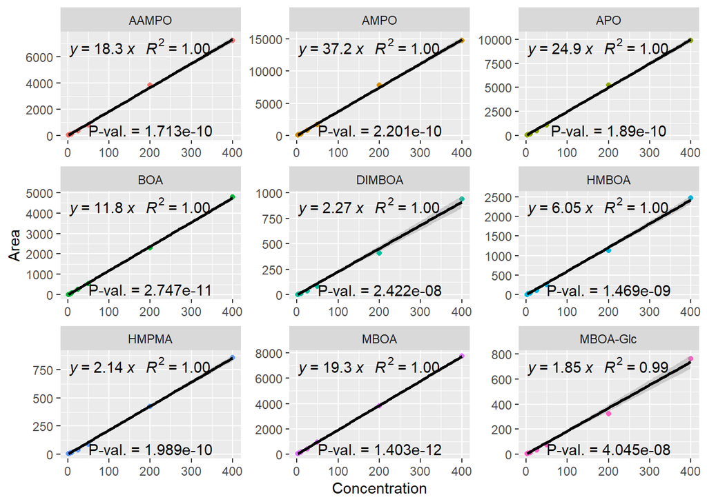

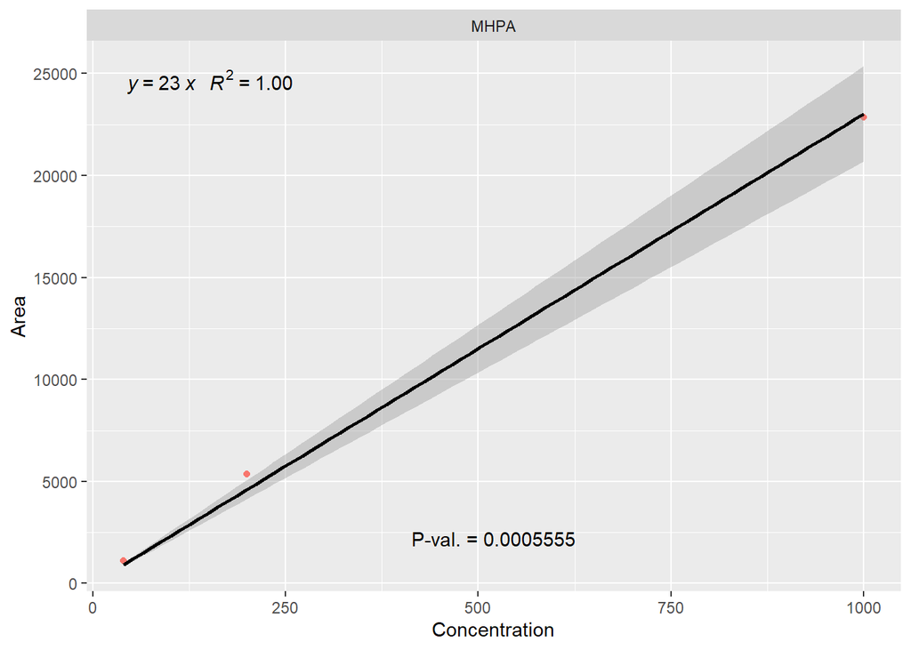

## Data formatting

Pairs - LMB2 + LBA21 - LMB2 pure - LMB2 + LMG1 - LMB2 + LMN1 - LMB2 + LMX9 - LMB2 + LMX92 - LMB2 + LMX922 - LMB2 + LMX923 - LMB2 + LMX9231 - LMB2 + LST17

Dropout - complete community - metSC: LMB2, LBA21, LMG1, LMN1, LST17, LMX9, LMX9231 - for each dropout community one strain is left out

SynComs - metSC: LMB2, LBA21, LMG1, LMN1, LST17, LMX9, LMX9231 - metSC2: LMB2, LBA21, LMG1, LMN1, LST17, LMX9, LMX922

reduced SynComs - SC3: LMB2, LMX9, LMX9231 - SC32: LMB2, LMX9, LMX922

```
##    #    Name    Type Std_conc   RT      Area IS Area  Response Detection Flags
## 1 36 NBC_d_D Analyte       NA 3.72     2.755      NA     2.755              bb
## 2 42 NBC_c_D Analyte       NA 3.73     2.326      NA     2.326              bb
## 3 45 NBC_d_M Analyte       NA 3.74 38586.504      NA 38586.504              bb
## 4 53 NBC_c_M Analyte       NA 3.74 24302.777      NA 24302.777              bb
##    ng/mL %Dev Compound   M Strain T Treatment experiment Strain_exp   Slope
## 1    0.7   NA     MBOA 165    NBC D      DMSO    dropout      NBC_d 19.2871
## 2    0.7   NA     MBOA 165    NBC D      DMSO      combo      NBC_c 19.2871
## 3 2015.3   NA     MBOA 165    NBC M      MBOA    dropout      NBC_d 19.2871
## 4 1269.5   NA     MBOA 165    NBC M      MBOA      combo      NBC_c 19.2871
##   Area_sample    ng_sample         uMol     cols
## 1      137.75 7.142080e+00   0.04328533 darkblue
## 2      116.30 6.029937e+00   0.03654507 darkblue
## 3  1929325.20 1.000319e+05 606.25394025 darkblue
## 4  1215138.85 6.300267e+04 381.83439255 darkblue
```

# Plottiing

## quantitative data

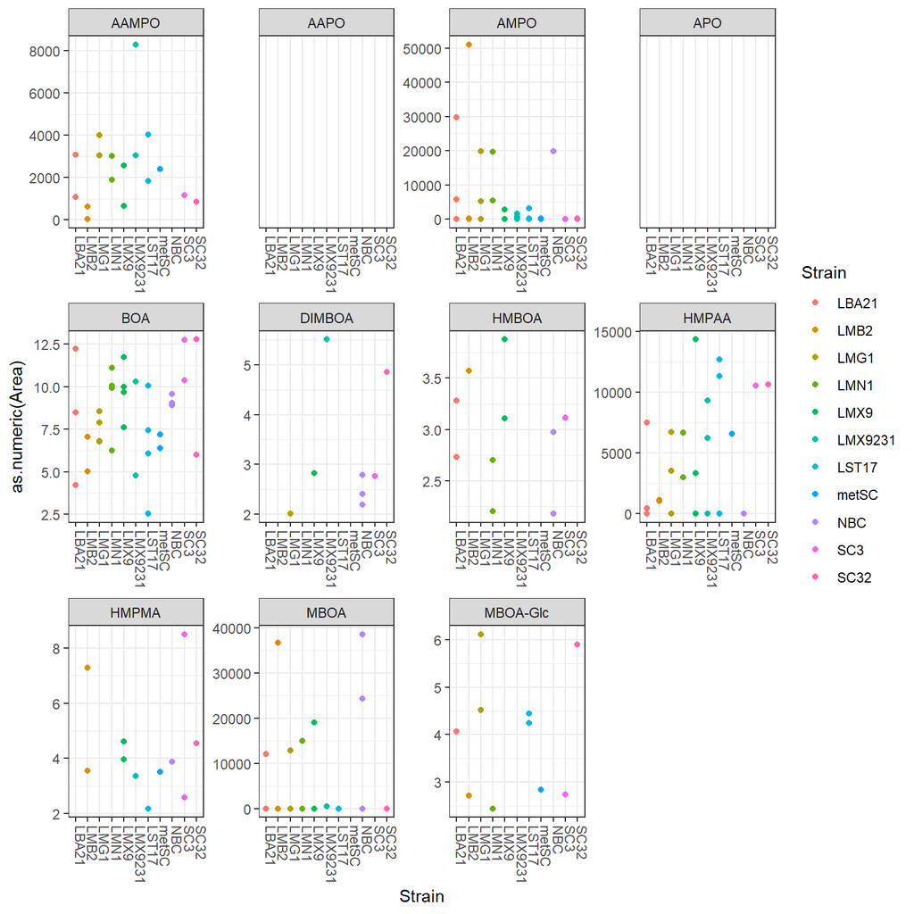

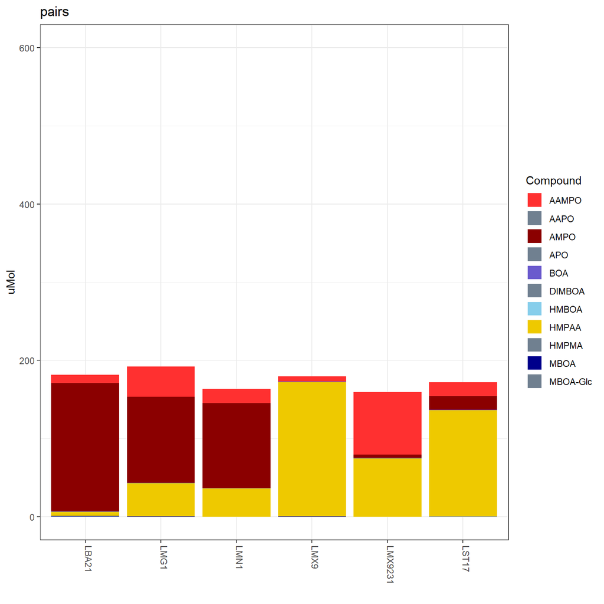

MBOA degradation in paired communities of LMB2 and other strains

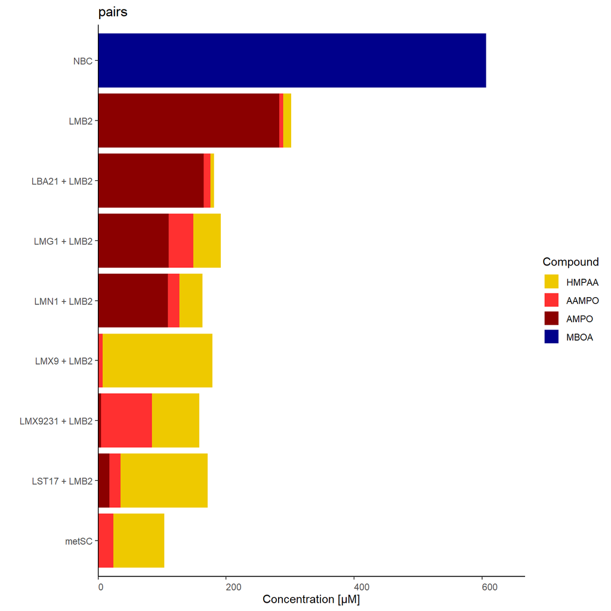

Deradation of MBOA in metSC dropout communities

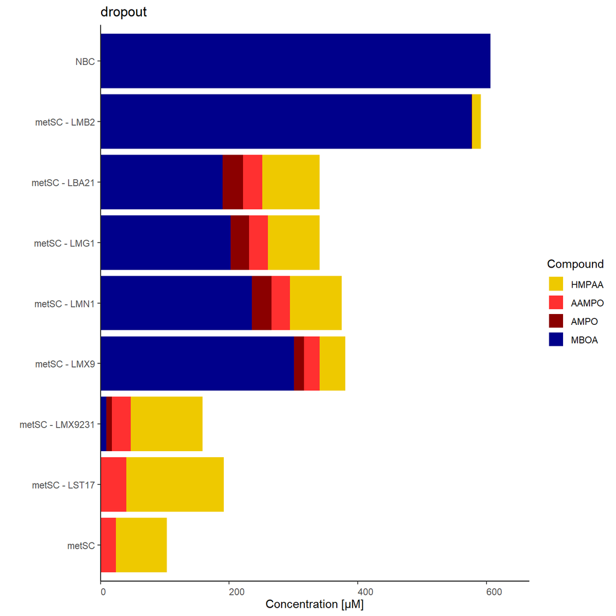

Export of data

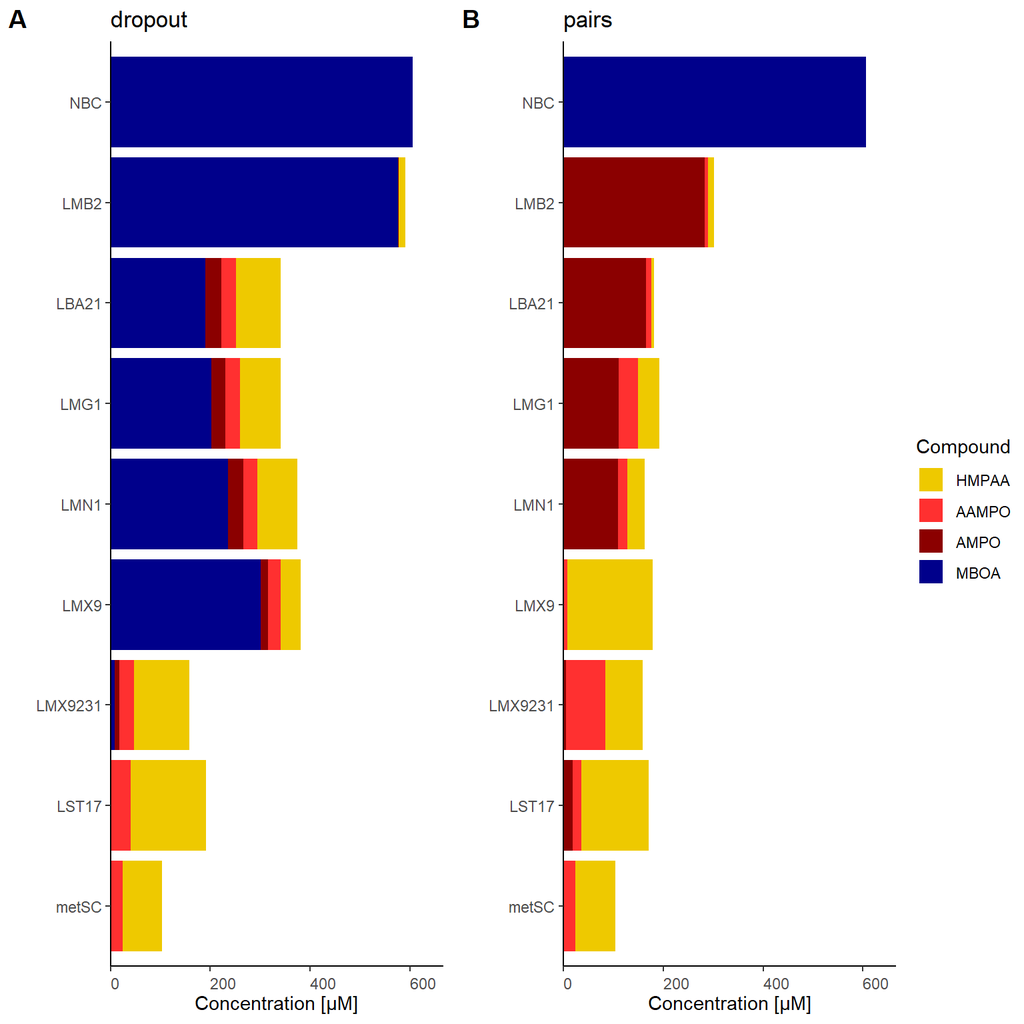